# Map Testing & Report Planning

Lee LeBoeuf, Beth Mitchell

2023-10-03

As many scientists predicted, we are already experiencing the beginning effects of climate change. Already, we see evidence that these effects [disproportionality impact low-income countries](https://www.theguardian.com/global-development/2022/jan/14/worlds-poorest-bear-brunt-of-climate-crisis-10-underreported-emergencies) and low-income communities in the [United States](https://www.npr.org/2021/07/14/1015983700/extreme-heat-is-getting-worse-for-low-income-non-white-americans-a-new-study-sho). In urban areas in the United States, [rising temperatures are most felt by low-income families](https://www.npr.org/2019/09/03/754044732/as-rising-heat-bakes-u-s-cities-the-poor-often-feel-it-mosthttps://www.npr.org/2019/09/03/754044732/as-rising-heat-bakes-u-s-cities-the-poor-often-feel-it-most) who tend to be concentrated in residential areas with high amounts of concrete and low amounts of green space.

These temperature disparities will further exacerbate disparities in housing costs ([like air conditioning](https://journals.sagepub.com/doi/10.1177/0956247816655676)) and [health outcomes](https://www.epa.gov/heatislands/heat-island-impacts).

Below, we map temperature readings across the city along with demographic information to see which communities of people in Charlottesville will be most impacted by urban heat island effects.

### Daily Temperature Fluctuations

Obviously, outside temperatures are not consistent across an entire day. Urban heat islands form when heat gets trapped in concrete and other industrial material, so the gradual increases in temperature you would expect to see the longer the sun is out is amplified.

The maps below temperature readings around the City of Charlottesville in the morning, afternoon, and evening from the same day. Seeing the progression of increasing temperatures throughout the day highlights how concrete-heavy areas trap heat while green spaces manage to regulate and cool the temperature. The larger disparities in the evening also coincide with the hours when families are more likely to be home and feel the differences–in the evening after work.

- Add emphasis that green spaces that were warm in the afternoon begin to cool by evening.
- Add explanation that we’re looking at census maps.

[interactive chart not shown]

### Filtered maps

#### Evening temperatures

[interactive chart not shown]

#### Black residents

[interactive chart not shown]

#### White residents

[interactive chart not shown]

#### Hispanic residents

[interactive chart not shown]

### Scatterplot

- Add explanation of trend line and how to interpret the scatterplots
- Could add correlations?

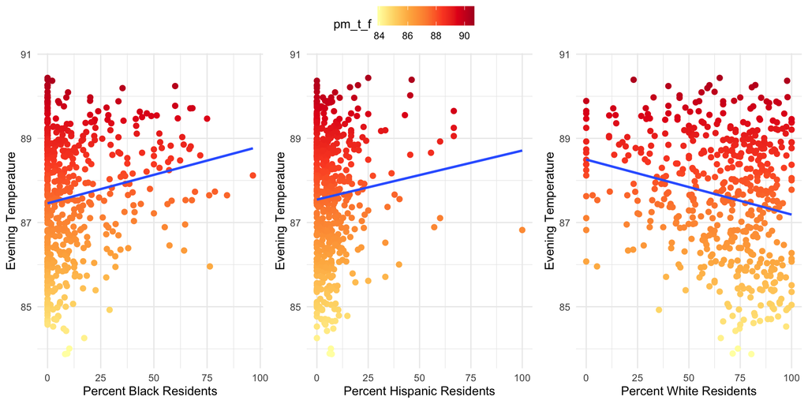